# Про возраст и инверсивность рыб

## Особенности построения модели

1. Из анализа были исключены возрастные группы 1+, и более 7+. Это связано с очень малыми объемами выборок по этим группам.То есть модель будет описывать только возрастной диапазон 2+ - 7+.
2. Была построена модель следующего вида.

$\eta = b_0 + b_1 Sex_{Male} + b_2(Age) + Interaction$

где

$\eta$ – логит-преобразованная вероятность встретить реверсивную рыбу.

## Результаты

Значимой зависимости вероятности встречи инверсивных рыб от пола выявлено не было (Таблица 1). Нет и значимого взаимодействия предикторов. Зависимость вероятности встретить инверсивную особь от возраста (в исследованном диапазоне) оказалась статистически значимой (Таблица 1).

Таблица 1. Параметры модели.

| term | estimate | std.error | statistic | p.value |
| --- | --- | --- | --- | --- |
| (Intercept) | -1.477 | 0.157 | -9.437 | 0.000 |
| Age | 0.094 | 0.035 | 2.681 | 0.007 |
| SexMale | 0.083 | 0.233 | 0.353 | 0.724 |
| Age:SexMale | 0.008 | 0.055 | 0.151 | 0.880 |

Полученная модель (Рисунок 1) предсказывает рост вероятности встретить инверсивную рыбу по мере увеличения возраста.

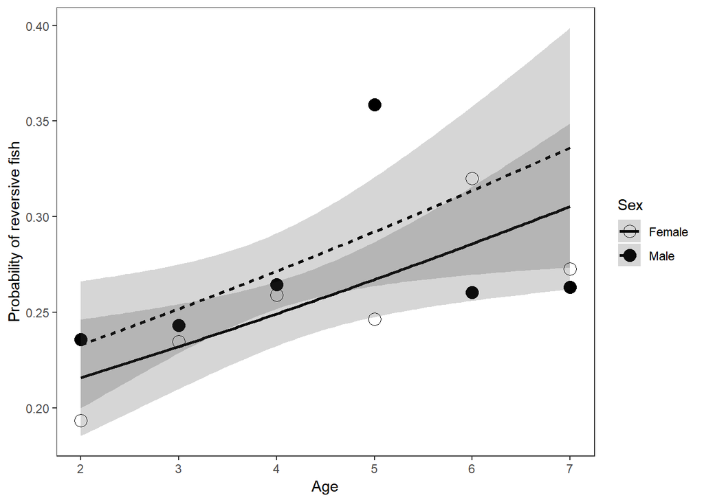

**Рисунок 1.** Зависимость доли инверсивных особей от возраста. Линии отражают предсказание модели.

Что еще сказать, глядя на эти графики, не знаю. Видно, что возрастное распределение “аномально”, виден недолов младших когорт. Но это ведь, как я понимаю, результат того, что ловили там, где молодь не живет…

В принципе, если есть желание, то по этим данным можно приблизительно (очень приблизительно) реконструировать кривые выживания для левых и правых рыб. Но это будет так себе по надежности.

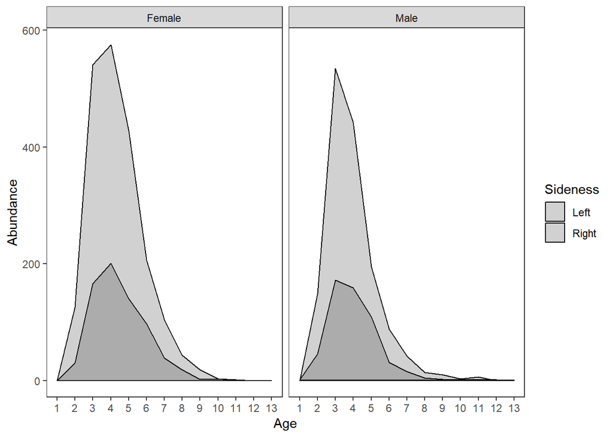

**Рисунок 2.** Возрастные распределения лево- и правосторонних камбал среди разных полов.

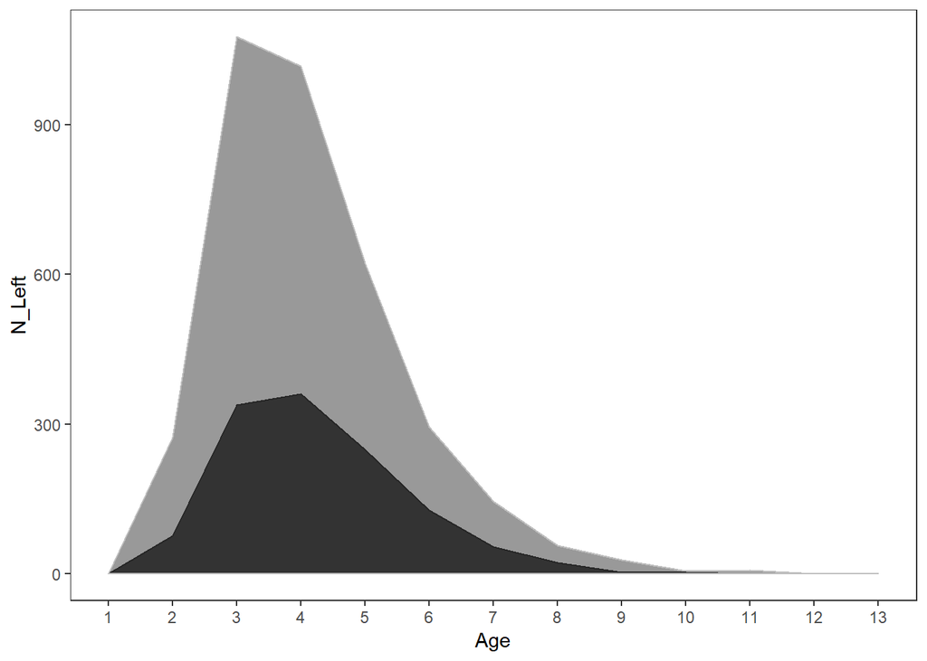

**Рисунок 3.** Возрастные распределения лево- и правосторонних камбал (оба пола объединены)

## Биологическая трактовка

Основное наблюдение осталось неизменным - чем старше рыба тем выше вероятность встретить инверсивную особь. То есть, фактор действующих против левосторонних рыб, особо сильно действует на ранних стадиях развития, но смягчается на более поздних.